# ass3

Sasa

2024-05-16

## 2

### (1)

sample a dataset:

```r
library('wiqid')
set.seed(517)
y <- rep(0,10)

x <- runif(10,)
n <- rep(0,10)
for(j in 1:10){
  while(n[j] == 0){
    n[j] <- rpois(1,5)
  }
}

alpha <- rt3(1,0,2,4)
beta <- rt3(1,0,1,4)

for(j in 1:10){
  theta <- exp(alpha+beta*x[j])/(1+exp(alpha+beta*x[j]))
  y[j] <- rbinom(1,n[j],theta)
}
```

```r
x; n; y
```

```
##  [1] 0.3886167365 0.2283110241 0.1406541099 0.9991578388 0.0009239637
##  [6] 0.6156288928 0.3887772406 0.6663700440 0.2097753154 0.8766466684
```

```
##  [1] 5 2 4 6 4 5 5 4 6 3
```

```
##  [1] 2 0 4 0 2 2 2 1 3 0
```

### (2)

Compute the joint posterior distribution at a grid of points (α,β), to determine a positive function g(α,β) proportional to p(α,β).

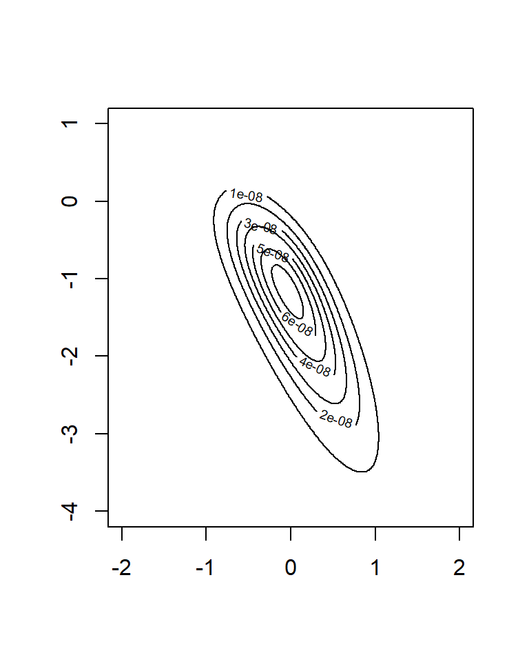

```r
q <- function(alpha, beta){
  p <- dt3(alpha,0,2,4) * dt3(beta,0,1,4)
  for(j in 1:10){
    theta <- exp(alpha+beta*x[j])/(1+exp(alpha+beta*x[j]))
    p <- p * dbinom(y[j],n[j],theta)
  }
  return(p)
}

alpha <- seq(-2,2,length = 400)
beta <- seq(-4,1,length = 500)

z <- outer(alpha, beta, q)
contour(alpha, beta, z)
```

mean: (0, -1.3) var: (1, 4); cov: -1

Choose normal distribution with the above mean and sigma matrix as sampling distribution; First to determine constant M:

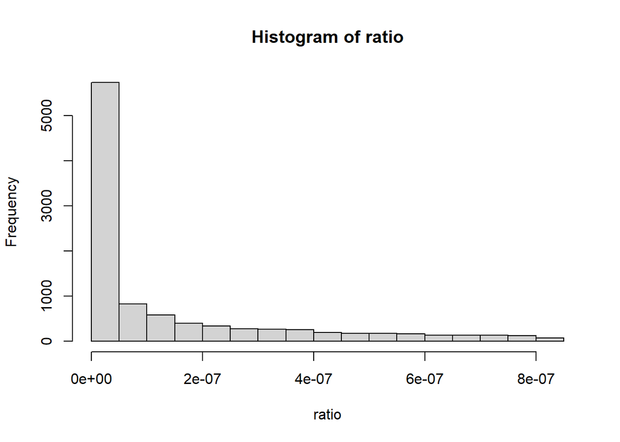

```r
library('mnormt')

set.seed(517)
sample_size <- 10000
ratio <- rep(0,sample_size)

mu <- c(0, -1.3)
sigma <- matrix(c(1,-1,-1,4), ncol= 2)

for(i in 1:sample_size){
  s <-  rmnorm(1,mu,sigma)
  g <-  dmnorm(s,mu,sigma)
  ratio[i] <- q(s[1],s[2])/g
}

hist(ratio)
```

```r
max(ratio)
```

```
## [1] 8.281918e-07
```

Set M = 8.3e-07,now we are ready to do rejection sampling:

```r
set.seed(517)
sample_size <- 10000
sample <- matrix(0,sample_size,2)
k <- 0

for(i in 1:sample_size){
  s <-  rmnorm(1,mu,sigma)
  g <-  dmnorm(s,mu,sigma)
  ratio <- q(s[1],s[2])/(g*8.3e-07)

  if(ratio < 1){
    if(runif(1) < ratio){
      k <- k+1
      sample[k,] <- s
    }
  }else{
    print('ratio larger than 1')
    print(ratio)
  }
}

k
```

```
## [1] 1632
```

```r
sample <- sample[1:1000, ]
```

### (3)

Determine the posterior mode with covariance matrix:

```r
library('dplyr')
```

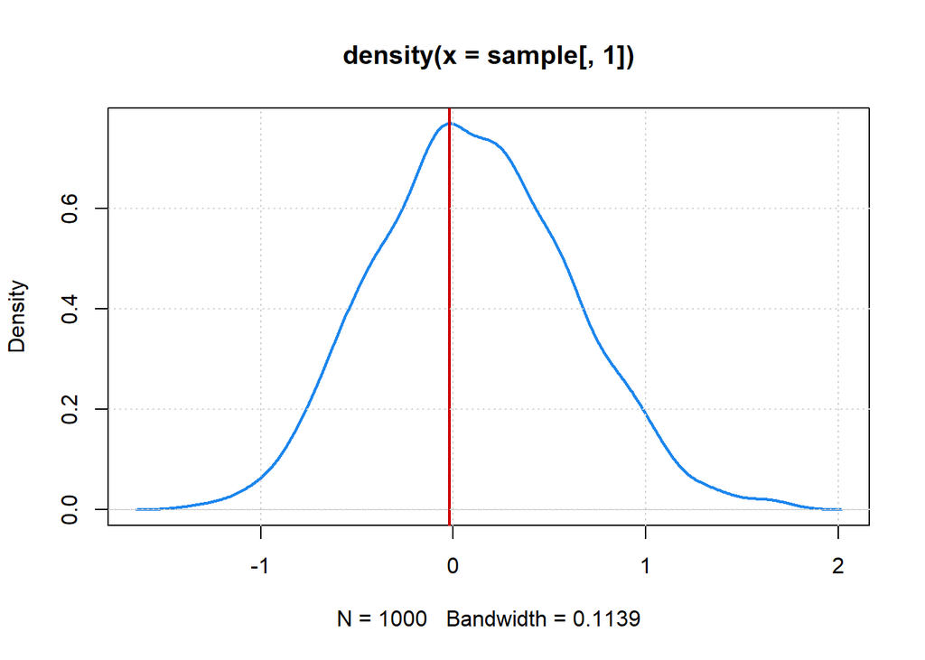

```r
den <- density(sample[,1])
denx=den$x
deny=den$y
den %>% plot(lwd = 2, col = "dodgerblue2")
denx[which.max(deny)] %>% abline(v = ., lwd = 2, col = "red3")
grid()
```

```r
denx[which.max(deny)]  ## -0.02037278
```

```
## [1] -0.02037278
```

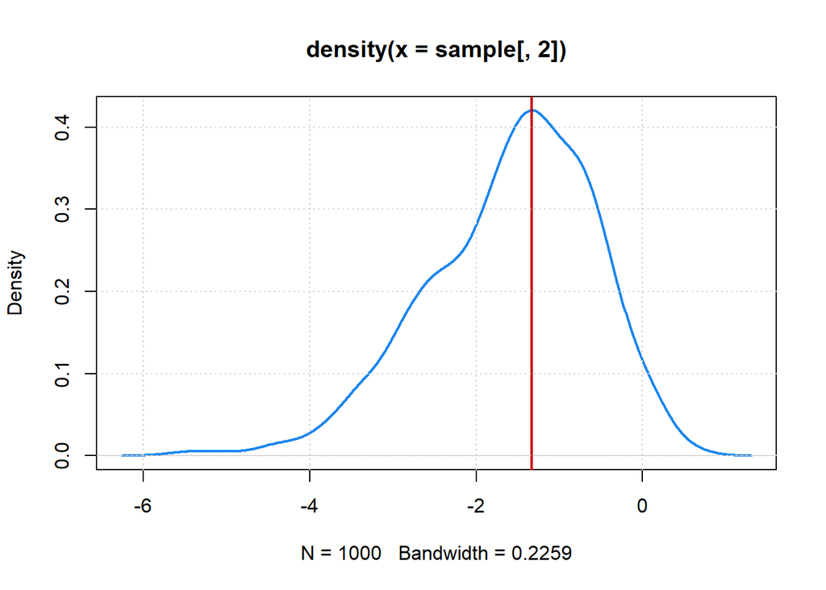

```r
den <- density(sample[,2])
denx=den$x
deny=den$y
den %>% plot(lwd = 2, col = "dodgerblue2")
denx[which.max(deny)] %>% abline(v = ., lwd = 2, col = "red3")
grid()
```

```r
denx[which.max(deny)]  ## -1.330051
```

```
## [1] -1.330051
```

```r
var(sample)
```

```
##            [,1]       [,2]
## [1,]  0.2538114 -0.3952204
## [2,] -0.3952204  0.9987149
```

Approximate the posterior density for (α,β) by a normal with the above determined parameter:

```r
library(gridExtra)
```

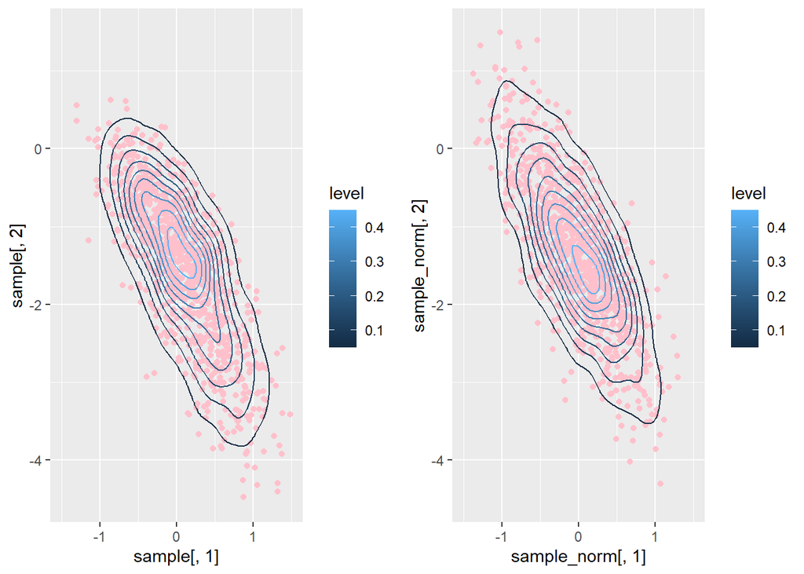

```r
library(ggplot2)

plot1 <- ggplot(as.data.frame(sample), aes(x = sample[,1], y = sample[,2])) +
  geom_point(col = 'pink') +
  geom_density_2d(aes(colour = after_stat(level)))+
  scale_x_continuous(limits = c(-1.5, 1.5)) +
  scale_y_continuous(limits = c(-4.5, 1.5))


mu <- c(-0.02, -1.33)
sigma <- var(sample)
sample_norm <- rmnorm(1000, mu, sigma)

plot2 <- ggplot(as.data.frame(sample_norm), aes(x = sample_norm[,1], y = sample_norm[,2])) +
  geom_point(col = 'pink') +
  geom_density_2d(aes(colour = after_stat(level)))+
  scale_x_continuous(limits = c(-1.5, 1.5)) +
  scale_y_continuous(limits = c(-4.5, 1.5))

grid.arrange(plot1, plot2, nrow = 1)
```

### (4)

Generate random draws from the two-dimensional $t_4$ distribution with that center and scale matrix, first use importance sampling to estimate the posterior mean of α+β and α-β:

```r
library('mvtnorm')
sample_size <- 1000
w <- rep(0,sample_size)
aw <- rep(0,sample_size)
mw <- rep(0,sample_size)

for(i in 1:sample_size){
  s <- rmvt(1,df = 4, delta = mu, sigma = sigma)
  g <- dmvt(s,df = 4, delta = mu, sigma = sigma)

  w[i] <- q(s[1], s[2])/g
  aw[i] <- (s[1]+s[2])*w[i]
  mw[i] <- (s[1]-s[2])*w[i]
}

add <- sum(aw)/sum(w)
minus <- sum(mw)/sum(w)
```

Then obtain the posterior mean of α and β:

```r
(add+minus) / 2
```

```
## [1] -0.004717897
```

```r
(add-minus) / 2
```

```
## [1] -1.31817
```

### (5)

ESS:

```r
w_n <- rep(0,sample_size)
for (i in 1:sample_size) {
  w_n[i] <- (w[i]/sum(w))^2
}

1/sum(w_n)
```

```
## [1] 463.1388
```

## 3

### (2)

Draw a contour plot of the unnormalized marginal posterior density of the hyperparameters on a grid of values:

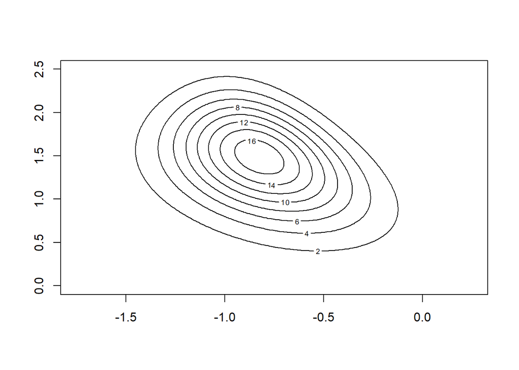

```r
t1 <- seq(-1.75,0.25, length=200)
t2 <- seq(0,2.5, length=250)
n <- c(58,90,48,57,103,57,86,112,273,64)
y <- c(16,9,10,13,19,20,18,17,35,55)

p <- function(t1,t2){
  a <- exp(t1+t2)/(1+exp(t1))
  b <- exp(t2)/(1+exp(t1))

  p <- (10^196)*a*b*(a+b)^(-2.5)
  for (i in 1:10) {
    p <- p*beta(a+y[i], b+n[i]-y[i])/beta(a,b)
  }
  return(p)
}

p <- Vectorize(p)
z <- outer(t1,t2,p)
contour(t1,t2,z)
```

Draw simulations from the joint posterior distribution of the paremeters and hyperparameters:

Draw 1000 simulations of $log(α/β)$ and $log(α+β)$:

```r
N = 1000
f_t1 = rowSums(z)
row = sample(1:200, N, replace=T, prob = f_t1)
t1_sample = t1[row]

t2_sample = numeric(N)
for (i in 1:N){
  col = sample(1:250, 1, prob=z[row[i], ])
  t2_sample[i] = t2[col]
}
```

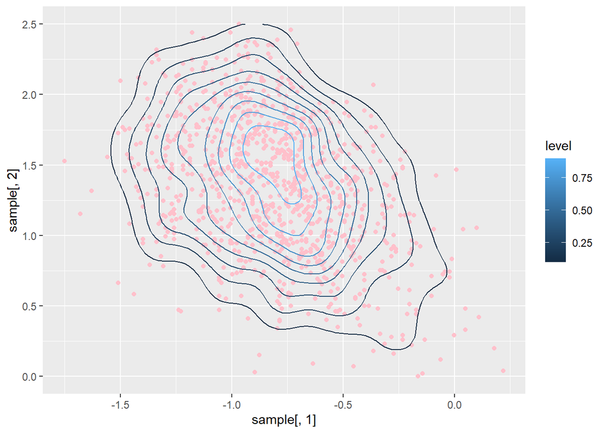

```r
library(ggplot2)
sample <- as.data.frame(cbind(t1_sample,t2_sample))

ggplot(sample, aes(x = sample[,1], y = sample[,2])) +
  geom_point(col = 'pink') +
  geom_density_2d(aes(colour = after_stat(level)))
```

Transform them to $(α, β)$ scale:

```r
alpha_sample <- exp(t1_sample+t2_sample)/(1+exp(t1_sample))
beta_sample <- exp(t2_sample)/(1+exp(t1_sample))
```

Sample $θ_j$ from its conditional posterior distribution:

```r
theta_sample <- matrix(rep(0,10*1000), ncol=10)

for (j in 1:10) {
  for (i in 1:1000) {
    theta_sample[i,j] <- rbeta(1,alpha_sample[i]+y[j], beta_sample[i]+n[j]-y[j])
  }
}
```

### (3)

```r
data <- as.data.frame(c(y/n))
colnames(data) <- 'raw_proportions'
data$mode <- rep(0,10)
data$median <- rep(0,10)
data$upper <- rep(0,10)
data$lower <- rep(0,10)
```

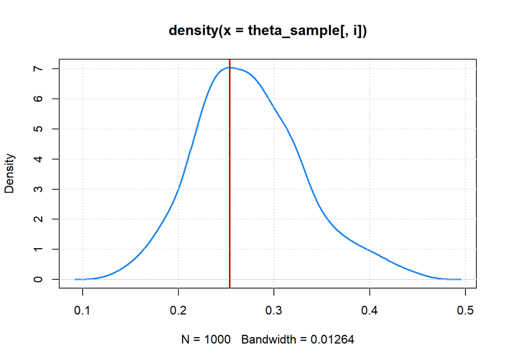

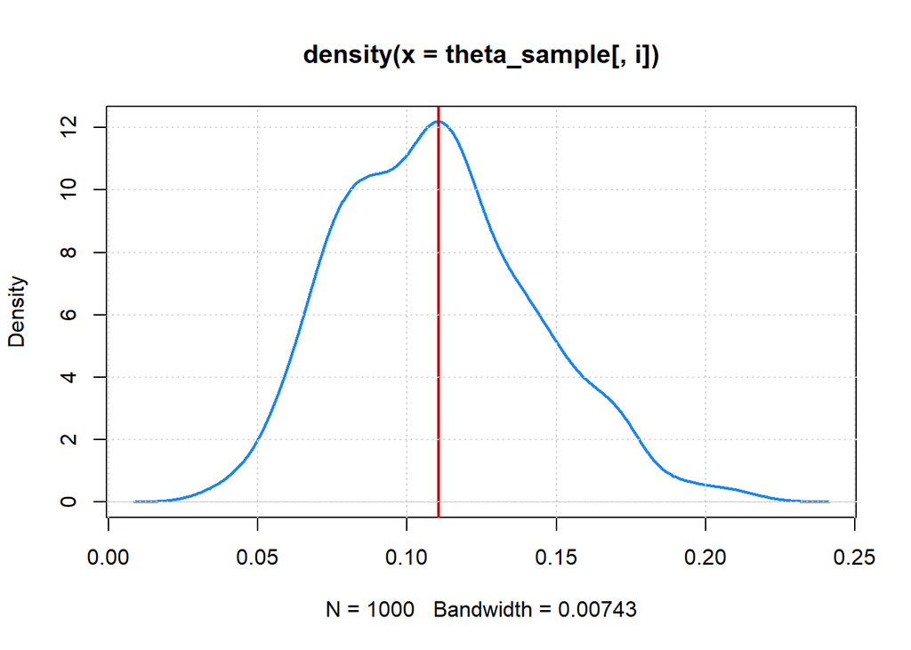

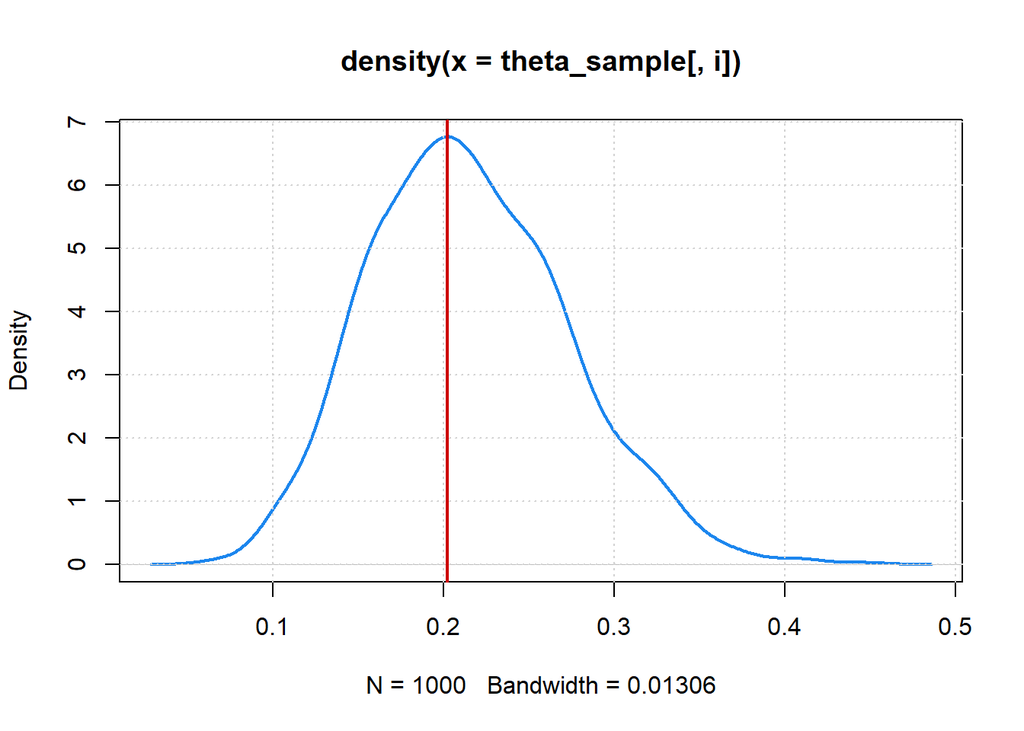

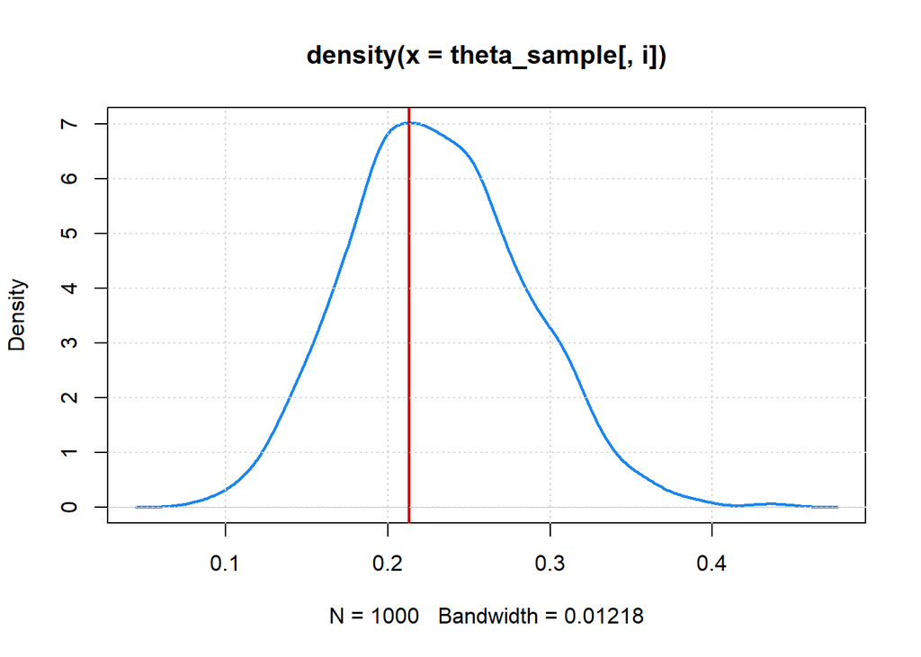

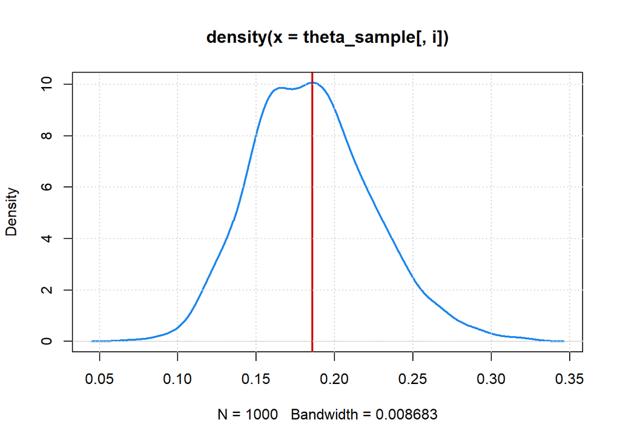

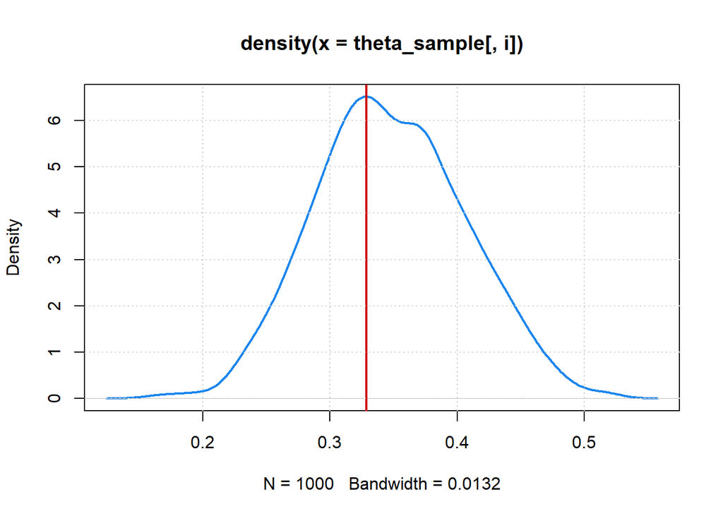

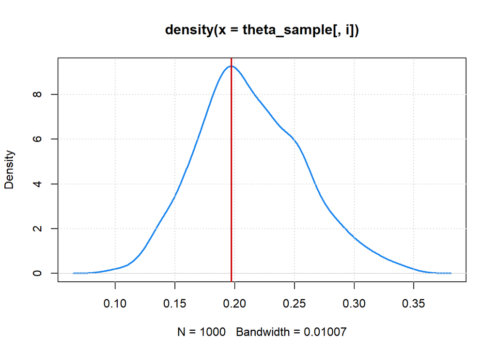

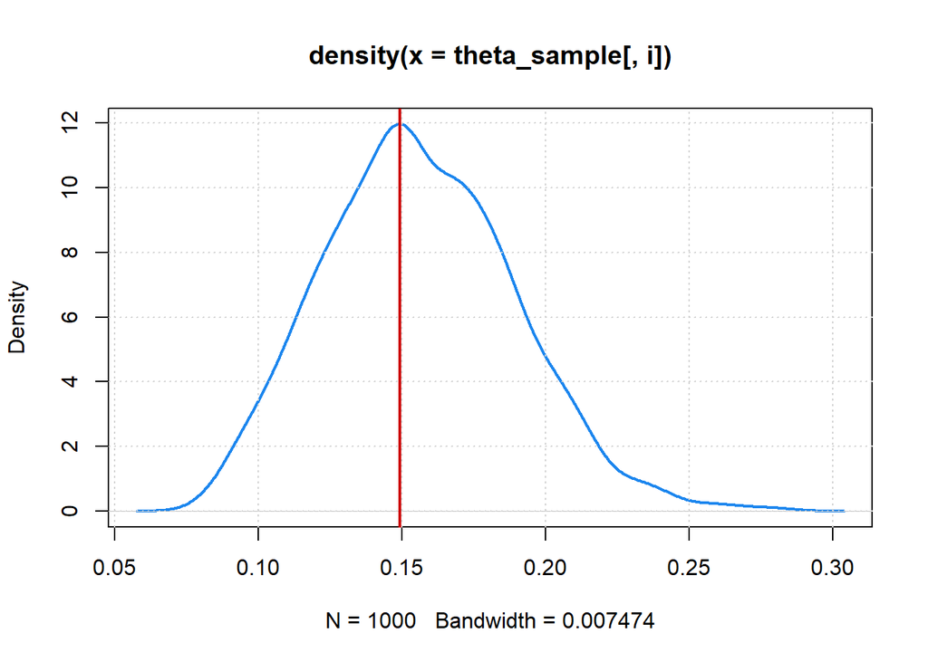

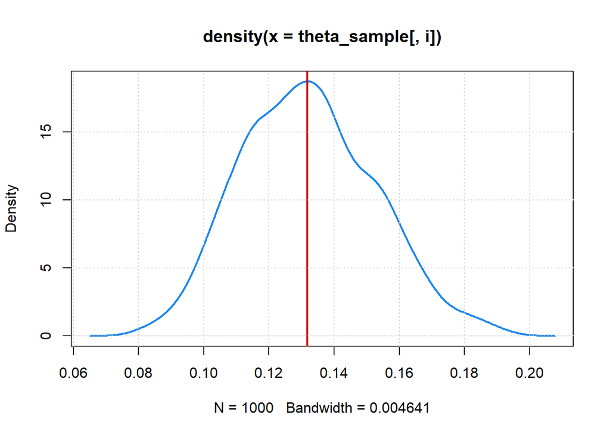

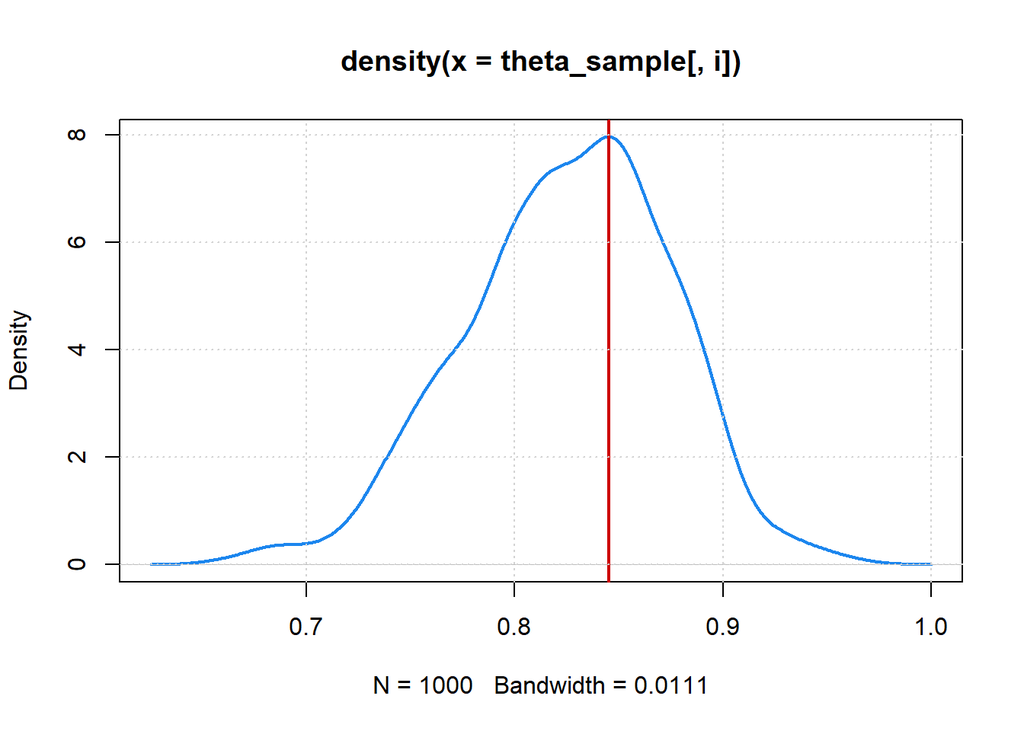

```r
for (i in 1:10) {
  den <- density(theta_sample[,i])
  denx=den$x
  deny=den$y
  den %>% plot(lwd = 2, col = "dodgerblue2")
  denx[which.max(deny)] %>% abline(v = ., lwd = 2, col = "red3")
  grid()

  data$mode[i] <- denx[which.max(deny)]
}
```

```r
for(i in 1:10){
  data$upper[i] <- sort(theta_sample[,i])[50]
  data$median[i] <- sort(theta_sample[,i])[500]
  data$lower[i] <- sort(theta_sample[,i])[950]
}

data[, c(1,2,3)]
```

```
##    raw_proportions      mode    median
## 1        0.2758621 0.2536709 0.2705249
## 2        0.1000000 0.1105277 0.1080600
## 3        0.2083333 0.2018757 0.2101279
## 4        0.2280702 0.2130415 0.2270705
## 5        0.1844660 0.1857802 0.1831429
## 6        0.3508772 0.3285210 0.3444612
## 7        0.2093023 0.1972304 0.2090309
## 8        0.1517857 0.1491712 0.1537895
## 9        0.1282051 0.1317677 0.1310326
## 10       0.8593750 0.8452900 0.8286745
```

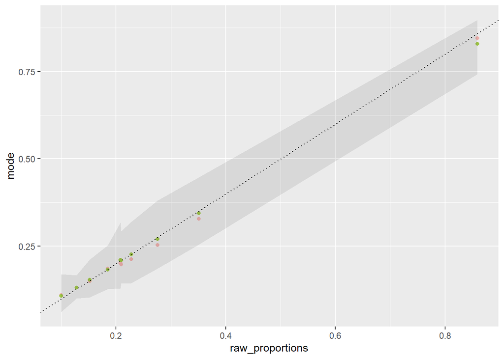

```r
ggplot(data, aes(x = raw_proportions)) +
  geom_point(aes(y = mode), col='#EEB0AC', )+
  geom_point(aes(y = median), col='#9EC545')+
  geom_abline(slope= 1, intercept= 0, linetype='dotted')+
  geom_ribbon(aes(ymin = lower, ymax = upper),
              alpha = 0.1)
```

Our posterior mode and posterior median matches with the raw proportions. Experiments with high observations(high raw proportion) has a larger bias.

### (4)

```r
data[, c(4,5)]
```

```
##         upper     lower
## 1  0.18598457 0.3809614
## 2  0.06146116 0.1694691
## 3  0.12910736 0.3178295
## 4  0.14457996 0.3198913
## 5  0.12759318 0.2527495
## 6  0.25416513 0.4468874
## 7  0.14350772 0.2930649
## 8  0.10383795 0.2120346
## 9  0.10037999 0.1666897
## 10 0.74192189 0.8972957
```